# 16 Functional Programming

Alyssa

3/24/2021

# Outline of class

Functional programming:

1. When to write a function
2. How to make a custom function

Lab:

1. Practice writing functions

# Why functions?

- Anytime you have a task that you want to use more than once
- Keeps your script clean
- Avoids mistakes with copy and paste
- Minimizes places where you need to update your code

## Anytime you have to do a task more then once…

Let’s use an example where we want to rescale data in multiple columns (value - min/(max - min)) **First create a dataframe of random numbers**

```r
library(tidyverse)
```

```r
df <- tibble::tibble(
  a = rnorm(10), # draws 10 random values from a normal distribution
  b = rnorm(10),
  c = rnorm(10),
  d = rnorm(10)
)

head(df)
```

```
## # A tibble: 6 x 4
##         a       b       c      d
##     <dbl>   <dbl>   <dbl>  <dbl>
## 1 -0.0197  1.31    0.496   0.508
## 2  0.0215  1.63   -0.281   0.540
## 3  1.45   -0.316  -1.42    0.713
## 4 -0.0995  0.0541  0.707  -0.792
## 5  1.27    1.28   -0.0758 -1.09
## 6  1.45   -0.393   1.11    0.223
```

```r
# Note our values will be different because they are random
```

**Rescale every column individually**

```r
df<-df %>%
  mutate(a = (a-min(a, na.rm = TRUE))/(max(a, na.rm = TRUE)-min(a, na.rm = TRUE)))
```

**Now copy and paste the same code for each column without making any mistakes**

```r
df<-df %>%
  mutate(a = (a-min(a, na.rm = TRUE))/(max(a, na.rm = TRUE)-min(a, na.rm = TRUE)),
         b = (b-min(b, na.rm = TRUE))/(max(b, na.rm = TRUE)-min(b, na.rm = TRUE)),
         c = (c-min(c, na.rm = TRUE))/(max(c, na.rm = TRUE)-min(c, na.rm = TRUE)),
         d = (d-min(d, na.rm = TRUE))/(max(d, na.rm = TRUE)-min(d, na.rm = TRUE)))
```

**We can write a function for this**

```r
rescale01 <- function(x) {
  value<-(x-min(x, na.rm = TRUE))/(max(x, na.rm = TRUE)-min(x, na.rm = TRUE))
  return(value)
}


df %>%
  mutate(a = rescale01(a),
         b = rescale01(b),
         c = rescale01(c),
         d = rescale01(d))
```

```
## # A tibble: 10 x 4
##         a     b     c       d
##     <dbl> <dbl> <dbl>   <dbl>
##  1 0.479  0.924 0.756 0.680
##  2 0.494  1     0.450 0.694
##  3 1      0.546 0     0.767
##  4 0.451  0.632 0.839 0.127
##  5 0.936  0.919 0.531 0
##  6 1.00   0.528 1     0.559
##  7 0.815  0.704 0.441 1
##  8 0.297  0.450 0.933 0.594
##  9 0.0938 0.410 0.479 0.124
## 10 0      0     0.589 0.00492
```

# Steps to creating a new function

1. You need to pick a name for the function. Here I’ve used **rescale01** because this function rescales a vector to lie between 0 and 1.
2. You list the inputs, or **arguments**, to the function inside function. Here we have just one argument. If we had more the call would look like function(x, y, z).
3. You place the code you have developed in **body of the function**, a { block that immediately follows function(…).
4. **return** tells us what values we want returned when you run the function

```r
rescale01 <- function(x) {
  value<-(x-min(x, na.rm = TRUE))/(max(x, na.rm = TRUE)-min(x, na.rm = TRUE))
  return(value)
}
```

Note: It is way easier to create a function when you already wrote the code rather than creating the function from scratch.

# Function to covert degrees fahrenheit to celcius

What is the calculation for F to C?

temp_C <- (temp_F - 32) * 5 / 9

**Step 1:** Name the function

```r
F_to_C <- function() {
}
```

**Step 2:** Put in the equation

```r
F_to_C <- function() {
  temp_C <- (temp_F - 32) * 5 / 9
}
```

**Step 3:** Decide what the arguments are

```r
F_to_C <- function(temp_F) {
  temp_C <- (temp_F - 32) * 5 / 9
}
```

**Step 4:** Decide what is being returned

```r
F_to_C <- function(temp_F) {
  temp_C <- (temp_F - 32) * 5 / 9
  return(temp_C)
}
```

**Test it**

```r
F_to_C(32)
```

```
## [1] 0
```

```r
F_to_C(212)
```

```
## [1] 100
```

# Think, Pair, Share

Write a function that converts celcius to kelvin. (Remember Kelvin is celcius + 273.15)

Equation:

temp_K <- temp_C + 273.15

**Step 1:** Name the function

```r
C_to_K <- function() {
}
```

**Step 2:** Put in the equation

```r
C_to_K <- function() {
  temp_K <- temp_C + 273.15
}
```

**Step 3:** Decide what the arguments are

```r
C_to_K <- function(temp_C) {
  temp_K <- temp_C + 273.15
}
```

**Step 4:** Decide what is being returned

```r
C_to_K <- function(temp_C) {
  temp_K <- temp_C + 273.15
  return(temp_K)
}
```

```r
C_to_K(30)
```

```
## [1] 303.15
```

# Making plots into a function

Let’s say you have a specifically formatted plot that you like and that you plan to use over and over again. By turning it into a function, you only have to code it once.

## Libraries

penguin dataset  
‘PNWColors’ for the color palette

```r
library(palmerpenguins)

library(PNWColors)
```

## Make a Plot

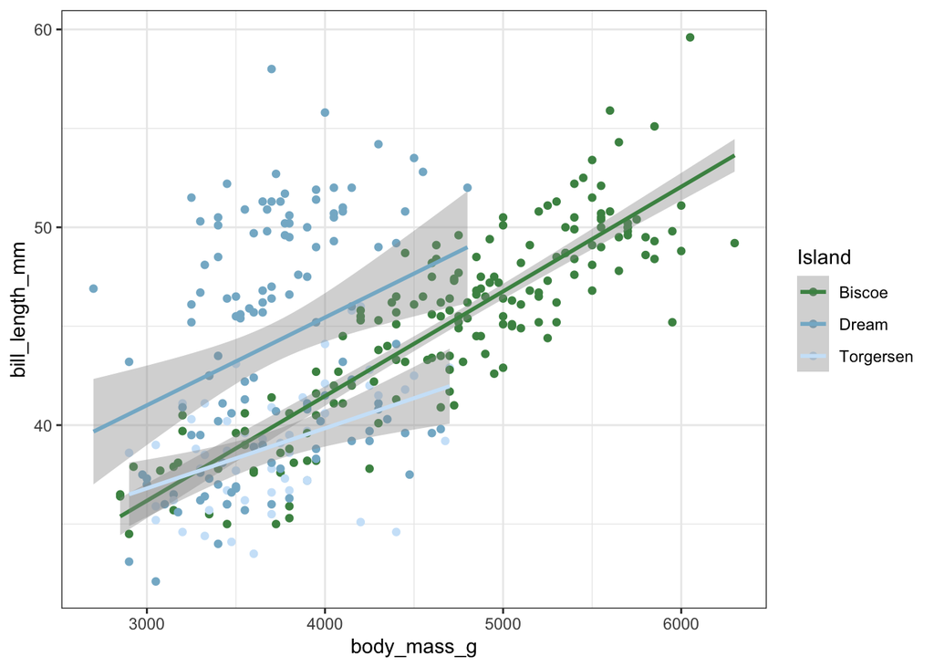

```r
ggplot(penguins, aes(x = body_mass_g, y = bill_length_mm, color = island))+
  geom_point() +
  geom_smooth(method = "lm") +
  scale_color_manual("Island",
                     values=pnw_palette("Lake",3, type = "discrete")) +
  theme_bw()
```

## make plot a function

Set up and name function:

```r
myplot<-function(){
ggplot(penguins, aes(x = body_mass_g, y = bill_length_mm, color = island))+
  geom_point() +
  geom_smooth(method = "lm") +
  scale_color_manual("Island",
                     values=pnw_palette("Lake",3, type = "discrete")) +
  theme_bw()

}
```

List arguments:  
Make the names broad so it can be applicable to several values

```r
myplot<-function(data, x, y){
ggplot(data, aes(x = {{x}}, y = {{y}} , color = island))+
  geom_point() +
  geom_smooth(method = "lm") +
  scale_color_manual("Island",
                     values=pnw_palette("Lake",3, type = "discrete")) +
  theme_bw()

}
```

Test it:

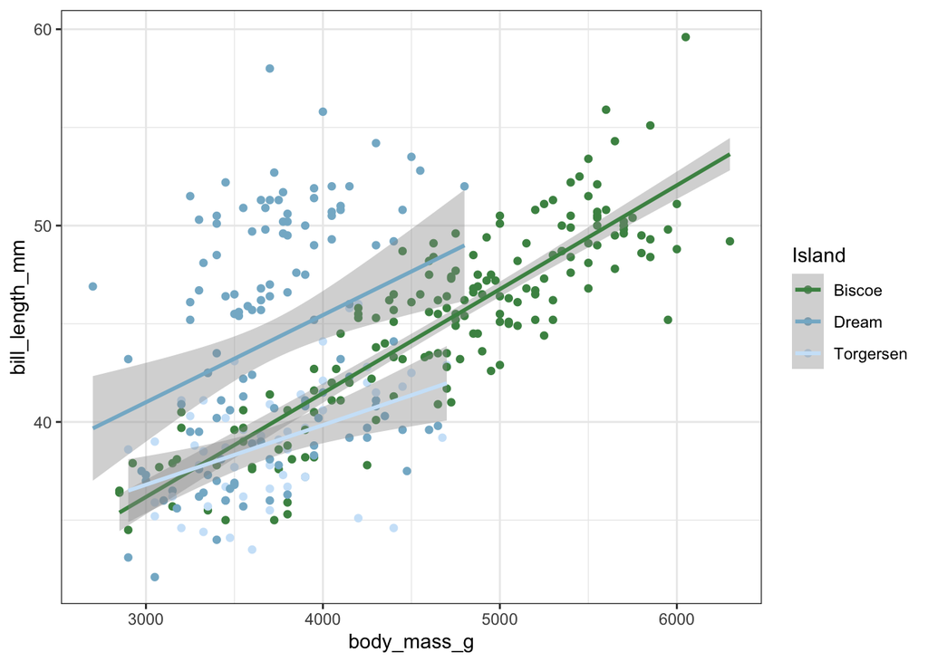

```r
myplot(data = penguins, x = body_mass_g, y = bill_length_mm)

myplot(data = penguins, x = body_mass_g, y = flipper_length_mm)
```

# Defaults

Let’s say you want to create a default for the function to always default to the penguins dataset. You can set those directly in the function.

```r
myplot<-function(data = penguins, x, y){
ggplot(data, aes(x = {{x}}, y = {{y}} , color = island))+
  geom_point() +
  geom_smooth(method = "lm") +
  scale_color_manual("Island",
                     values=pnw_palette("Lake",3, type = "discrete")) +
  theme_bw()

}
```

Now, you can just write…

```r
myplot(x = body_mass_g, y = flipper_length_mm)
```

# Layering the plot

You can also layer onto your plot using ‘+’ just like it is a regular ggplot to change things like labels.

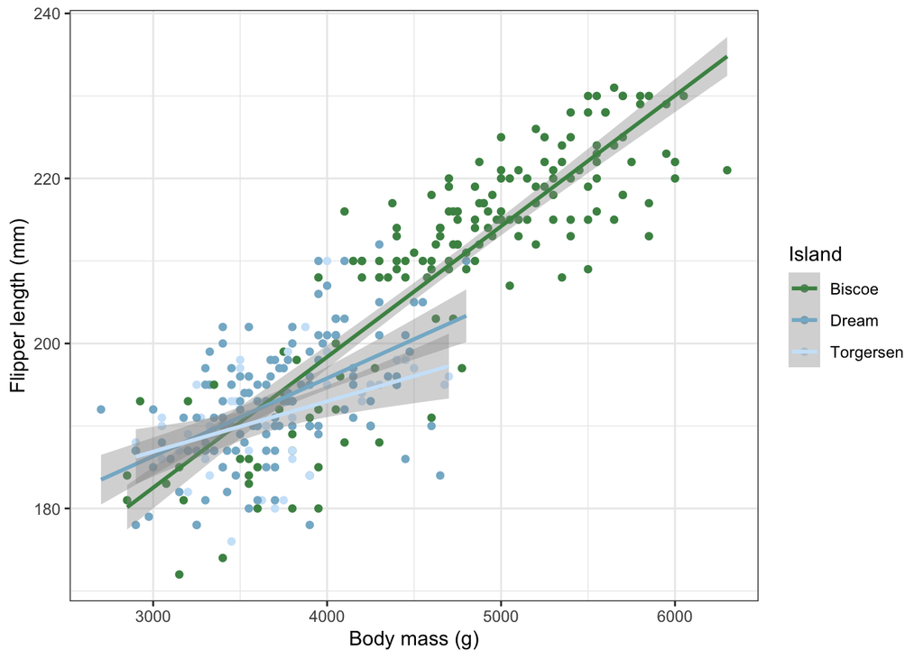

```r
myplot(x = body_mass_g, y = flipper_length_mm)+
  labs(x = "Body mass (g)",
       y = "Flipper length (mm)")
```

# Add if-else

Add an if-else statement for more flexibility.  
An aside on if-else statements….

Imagine you want a variable to be equal to a certain value if a condition is met. This is a typical problem that requires the if … else … construct. For instance:

```r
a <- 4
b <- 5
```

Suppose that *if* a > b then **f** should be = to 20, else **f** should be equal to 10. Using if/else we:

```r
if (a > b) { # my question
  f <- 20 # if it is true give me answer 1
    } else { # else give me answer 2
  f <- 10
}
```

When I type f I get…

```r
f
```

```
## [1] 10
```

# if-else and plotting

Using if…else… we can make our function even more flexible. Let’s say we want the option of adding the geom_smooth lines. We can create a variable that if set to TRUE add the geom_smooth, otherwise print without.

## First add a new argument for lines and make the default TRUE for ease

add ‘lines=TRUE’ to the defaults

```r
myplot<-function(data = penguins, x, y ,lines=TRUE){
ggplot(data, aes(x = {{x}}, y = {{y}} , color = island))+
  geom_point() +
  geom_smooth(method = "lm") +
  scale_color_manual("Island",
                     values=pnw_palette("Lake",3, type = "discrete")) +
  theme_bw()

}
```

## Next, add an if-else statement

```r
myplot<-function(data = penguins, x, y, lines=TRUE ){
if(lines==TRUE){
ggplot(data, aes(x = {{x}}, y = {{y}} , color = island))+
  geom_point() +
  geom_smooth(method = "lm") +
  scale_color_manual("Island",
                     values=pnw_palette("Lake",3, type = "discrete")) +
  theme_bw()
}
else{
ggplot(data, aes(x = {{x}}, y = {{y}} , color = island))+ #<<
  geom_point()+
  scale_color_manual("Island",
                     values=pnw_palette("Lake",3, type = "discrete")) +
  theme_bw()
}
}
```

## Test it

**With lines**

```r
myplot(x = body_mass_g, y = flipper_length_mm)
```

[output not shown]

**Without lines**

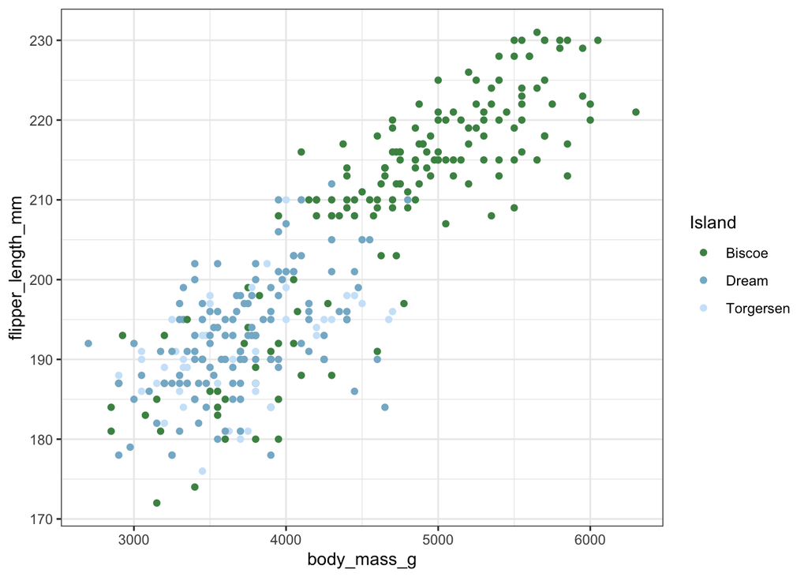

```r
myplot(x = body_mass_g, y = flipper_length_mm, lines = FALSE)
```